# Vectors and Matrices in R

R Workshop

2025-02-05

## Introduction

In R, vectors and matrices are fundamental data structures that allow us to work with collections of data. They are especially important in bioinformatics and RNA-seq analysis, where we often need to handle large sets of gene expression values or sample measurements.

## Vectors

A vector is a one-dimensional array that can hold elements of the same type (numeric, character, or logical).

### Creating Vectors

There are several ways to create vectors in R:

```r
# Using c() function (combine)
gene_expression <- c(156.7, 238.9, 184.3, 145.6)
gene_names <- c("BRCA1", "TP53", "EGFR", "KRAS")
is_significant <- c(TRUE, FALSE, TRUE, TRUE)

# Using : operator for sequences
sample_numbers <- 1:10  # Creates 1,2,3,...,10

# Using seq() function for more complex sequences
time_points <- seq(0, 48, by = 6)  # Creates 0,6,12,...,48

# Let's print our vectors to see what they look like
print("Gene Expression Values:")
```

```
## [1] "Gene Expression Values:"
```

```r
print(gene_expression)
```

```
## [1] 156.7 238.9 184.3 145.6
```

```r
print("Gene Names:")
```

```
## [1] "Gene Names:"
```

```r
print(gene_names)
```

```
## [1] "BRCA1" "TP53"  "EGFR"  "KRAS"
```

### Vector Operations

Vectors in R support element-wise operations:

```r
# RNA-seq example: normalizing expression values
raw_counts <- c(1200, 1500, 800, 2000)
scaling_factor <- 0.5
normalized_counts <- raw_counts * scaling_factor

# Adding vectors
control_expression <- c(100, 150, 80, 200)
treated_expression <- c(150, 180, 90, 250)
expression_difference <- treated_expression - control_expression

# Calculate fold change
fold_change <- treated_expression / control_expression

# Let's see our results
print("Normalized counts:")
```

```
## [1] "Normalized counts:"
```

```r
print(normalized_counts)
```

```
## [1]  600  750  400 1000
```

```r
print("Expression difference:")
```

```
## [1] "Expression difference:"
```

```r
print(expression_difference)
```

```
## [1] 50 30 10 50
```

```r
print("Fold change:")
```

```
## [1] "Fold change:"
```

```r
print(fold_change)
```

```
## [1] 1.500 1.200 1.125 1.250
```

### Vector Functions

R provides many useful functions for working with vectors:

```r
# Length of a vector
print("Length of gene_names:")
```

```
## [1] "Length of gene_names:"
```

```r
length(gene_names)  # Returns 4
```

```
## [1] 4
```

```r
# Summary statistics
print("Summary statistics for raw_counts:")
```

```
## [1] "Summary statistics for raw_counts:"
```

```r
mean(raw_counts)
```

```
## [1] 1375
```

```r
median(raw_counts)
```

```
## [1] 1350
```

```r
max(raw_counts)
```

```
## [1] 2000
```

```r
min(raw_counts)
```

```
## [1] 800
```

```r
sum(raw_counts)
```

```
## [1] 5500
```

```r
# Sort values
sorted_counts <- sort(raw_counts)
sorted_counts_desc <- sort(raw_counts, decreasing = TRUE)

print("Sorted counts (ascending):")
```

```
## [1] "Sorted counts (ascending):"
```

```r
print(sorted_counts)
```

```
## [1]  800 1200 1500 2000
```

```r
print("Sorted counts (descending):")
```

```
## [1] "Sorted counts (descending):"
```

```r
print(sorted_counts_desc)
```

```
## [1] 2000 1500 1200  800
```

```r
# Find unique values
unique_genes <- unique(gene_names)
print("Unique genes:")
```

```
## [1] "Unique genes:"
```

```r
print(unique_genes)
```

```
## [1] "BRCA1" "TP53"  "EGFR"  "KRAS"
```

### Accessing Vector Elements

Elements in vectors can be accessed using indices or logical conditions:

```r
# By position (index)
first_gene <- gene_names[1]  # Gets "BRCA1"
selected_genes <- gene_names[c(1, 3)]  # Gets "BRCA1" and "EGFR"

# By logical condition
high_expression <- raw_counts > 1000
high_expressed_genes <- gene_names[high_expression]

# Using which() function
significant_indices <- which(is_significant)
significant_genes <- gene_names[significant_indices]

# Let's see our results
print("First gene:")
```

```
## [1] "First gene:"
```

```r
print(first_gene)
```

```
## [1] "BRCA1"
```

```r
print("Selected genes:")
```

```
## [1] "Selected genes:"
```

```r
print(selected_genes)
```

```
## [1] "BRCA1" "EGFR"
```

```r
print("Highly expressed genes:")
```

```
## [1] "Highly expressed genes:"
```

```r
print(high_expressed_genes)
```

```
## [1] "BRCA1" "TP53"  "KRAS"
```

## Matrices

Matrices are two-dimensional arrays that also hold elements of the same type. They are particularly useful for representing expression data where rows might be genes and columns might be samples.

### Creating Matrices

```r
# Create a matrix from vectors
expression_matrix <- matrix(
  c(100, 200, 150, 300,
    120, 180, 160, 280,
    90, 220, 170, 320),
  nrow = 3,
  ncol = 4,
  byrow = TRUE
)

# Add row and column names
rownames(expression_matrix) <- c("Gene1", "Gene2", "Gene3")
colnames(expression_matrix) <- c("Sample1", "Sample2", "Sample3", "Sample4")

# Let's see our matrix
print("Expression Matrix:")
```

```
## [1] "Expression Matrix:"
```

```r
print(expression_matrix)
```

```
##       Sample1 Sample2 Sample3 Sample4
## Gene1     100     200     150     300
## Gene2     120     180     160     280
## Gene3      90     220     170     320
```

### Matrix Operations

```r
# Transpose a matrix
transposed_matrix <- t(expression_matrix)

# Matrix multiplication
# Useful for statistical calculations
correlation_matrix <- t(expression_matrix) %*% expression_matrix

# Element-wise operations
scaled_matrix <- expression_matrix * 2
log_matrix <- log2(expression_matrix)

print("Transposed Matrix:")
```

```
## [1] "Transposed Matrix:"
```

```r
print(transposed_matrix)
```

```
##         Gene1 Gene2 Gene3
## Sample1   100   120    90
## Sample2   200   180   220
## Sample3   150   160   170
## Sample4   300   280   320
```

```r
print("\nCorrelation Matrix:")
```

```
## [1] "\nCorrelation Matrix:"
```

```r
print(correlation_matrix)
```

```
##         Sample1 Sample2 Sample3 Sample4
## Sample1   32500   61400   49500   92400
## Sample2   61400  120800   96200  180800
## Sample3   49500   96200   77000  144200
## Sample4   92400  180800  144200  270800
```

```r
print("\nLog2 Transformed Matrix:")
```

```
## [1] "\nLog2 Transformed Matrix:"
```

```r
print(log_matrix)
```

```
##        Sample1  Sample2  Sample3  Sample4
## Gene1 6.643856 7.643856 7.228819 8.228819
## Gene2 6.906891 7.491853 7.321928 8.129283
## Gene3 6.491853 7.781360 7.409391 8.321928
```

### Accessing Matrix Elements

```r
# Access single element
value <- expression_matrix[1, 2]  # Row 1, Column 2

# Access entire row
gene1_expression <- expression_matrix[1, ]

# Access entire column
sample1_values <- expression_matrix[, 1]

# Access multiple rows/columns
subset_matrix <- expression_matrix[1:2, c(1,3)]

print("Value at position [1,2]:")
```

```
## [1] "Value at position [1,2]:"
```

```r
print(value)
```

```
## [1] 200
```

```r
print("\nExpression values for Gene1:")
```

```
## [1] "\nExpression values for Gene1:"
```

```r
print(gene1_expression)
```

```
## Sample1 Sample2 Sample3 Sample4
##     100     200     150     300
```

```r
print("\nValues for Sample1:")
```

```
## [1] "\nValues for Sample1:"
```

```r
print(sample1_values)
```

```
## Gene1 Gene2 Gene3
##   100   120    90
```

```r
print("\nSubset Matrix:")
```

```
## [1] "\nSubset Matrix:"
```

```r
print(subset_matrix)
```

```
##       Sample1 Sample3
## Gene1     100     150
## Gene2     120     160
```

## RNA-seq Example: Differential Expression Analysis

Let’s work through a complete example using RNA-seq data:

```r
# Create an expression matrix with 5 genes and 6 samples (3 control, 3 treated)
expression_data <- matrix(
  c(
    1200, 1300, 1250, 1800, 1900, 1850,  # Gene1
    800,  750,  780,  1200, 1180, 1220,   # Gene2
    2000, 2100, 2050, 2080, 2150, 2090,   # Gene3
    300,  320,  310,  900,  920,  880,    # Gene4
    1500, 1450, 1480, 1600, 1580, 1620    # Gene5
  ),
  nrow = 5,
  ncol = 6,
  byrow = TRUE
)

# Add gene and sample names
rownames(expression_data) <- c("Gene1", "Gene2", "Gene3", "Gene4", "Gene5")
colnames(expression_data) <- c("Ctrl1", "Ctrl2", "Ctrl3", "Treat1", "Treat2", "Treat3")

# Calculate mean expression for control and treated groups
control_means <- rowMeans(expression_data[, 1:3])
treated_means <- rowMeans(expression_data[, 4:6])

# Calculate fold changes
fold_changes <- treated_means / control_means

# Identify differentially expressed genes (fold change > 1.5)
is_differential <- abs(fold_changes) > 1.5
differential_genes <- rownames(expression_data)[is_differential]

# Let's visualize our results
print("Expression Data Matrix:")
```

```
## [1] "Expression Data Matrix:"
```

```r
print(expression_data)
```

```
##       Ctrl1 Ctrl2 Ctrl3 Treat1 Treat2 Treat3
## Gene1  1200  1300  1250   1800   1900   1850
## Gene2   800   750   780   1200   1180   1220
## Gene3  2000  2100  2050   2080   2150   2090
## Gene4   300   320   310    900    920    880
## Gene5  1500  1450  1480   1600   1580   1620
```

```r
print("\nControl Means:")
```

```
## [1] "\nControl Means:"
```

```r
print(control_means)
```

```
##     Gene1     Gene2     Gene3     Gene4     Gene5
## 1250.0000  776.6667 2050.0000  310.0000 1476.6667
```

```r
print("\nTreated Means:")
```

```
## [1] "\nTreated Means:"
```

```r
print(treated_means)
```

```
##    Gene1    Gene2    Gene3    Gene4    Gene5
## 1850.000 1200.000 2106.667  900.000 1600.000
```

```r
print("\nFold Changes:")
```

```
## [1] "\nFold Changes:"
```

```r
print(fold_changes)
```

```
##    Gene1    Gene2    Gene3    Gene4    Gene5
## 1.480000 1.545064 1.027642 2.903226 1.083521
```

```r
print("\nDifferentially Expressed Genes:")
```

```
## [1] "\nDifferentially Expressed Genes:"
```

```r
print(differential_genes)
```

```
## [1] "Gene2" "Gene4"
```

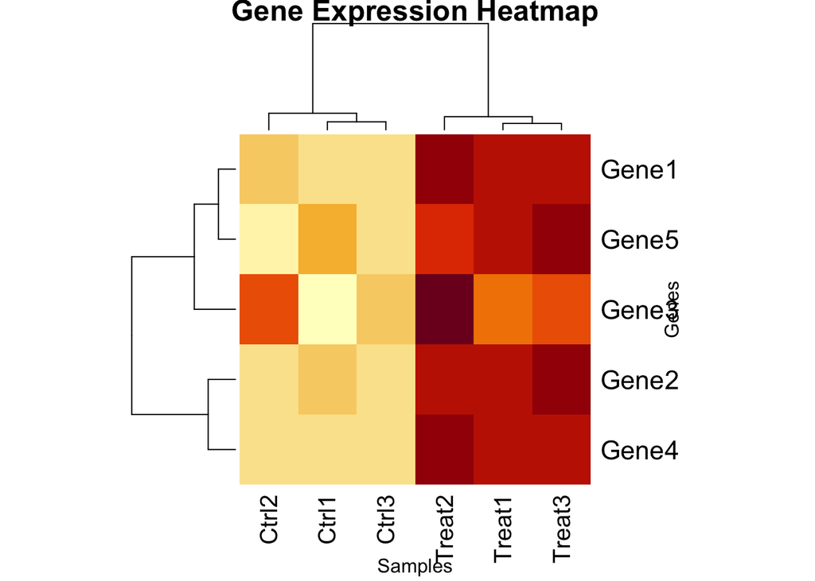

```r
# Create a simple heatmap of the expression data

heatmap(expression_data,
        main = "Gene Expression Heatmap",
        xlab = "Samples",
        ylab = "Genes",
        scale = "row")  # Scale rows for better visualization
```

## Practice Exercises

Try these exercises to test your understanding:

### Exercise 1: Vector Operations

Create two vectors of gene expression values and: 1. Calculate their mean expression 2. Find genes with expression > 1000 3. Calculate the fold change between them

```r
# Your code here
exp_condition1 <- c(1200, 800, 2000, 300, 1500)
exp_condition2 <- c(1800, 1200, 2080, 900, 1600)

# Calculate mean expression
mean_exp1 <- mean(exp_condition1)
mean_exp2 <- mean(exp_condition2)

# Find highly expressed genes
high_exp1 <- exp_condition1 > 1000
high_exp2 <- exp_condition2 > 1000

# Calculate fold changes
fold_changes <- exp_condition2 / exp_condition1

# Print results
print("Mean expression condition 1:")
```

```
## [1] "Mean expression condition 1:"
```

```r
print(mean_exp1)
```

```
## [1] 1160
```

```r
print("Mean expression condition 2:")
```

```
## [1] "Mean expression condition 2:"
```

```r
print(mean_exp2)
```

```
## [1] 1516
```

```r
print("Highly expressed in condition 1:")
```

```
## [1] "Highly expressed in condition 1:"
```

```r
print(which(high_exp1))
```

```
## [1] 1 3 5
```

```r
print("Fold changes:")
```

```
## [1] "Fold changes:"
```

```r
print(fold_changes)
```

```
## [1] 1.500000 1.500000 1.040000 3.000000 1.066667
```

### Exercise 2: Matrix Manipulation

Using the example RNA-seq matrix: 1. Extract expression values for specific genes 2. Calculate the mean expression per sample 3. Identify the highest expressed gene in each sample

```r
# Extract specific genes
gene1_expression <- expression_data["Gene1", ]

# Calculate mean per sample
sample_means <- colMeans(expression_data)

# Find highest expressed gene
max_expression <- apply(expression_data, 2, which.max)
highest_genes <- rownames(expression_data)[max_expression]

# Print results
print("Gene1 expression across samples:")
```

```
## [1] "Gene1 expression across samples:"
```

```r
print(gene1_expression)
```

```
##  Ctrl1  Ctrl2  Ctrl3 Treat1 Treat2 Treat3
##   1200   1300   1250   1800   1900   1850
```

```r
print("\nMean expression per sample:")
```

```
## [1] "\nMean expression per sample:"
```

```r
print(sample_means)
```

```
##  Ctrl1  Ctrl2  Ctrl3 Treat1 Treat2 Treat3
##   1160   1184   1174   1516   1546   1532
```

```r
print("\nHighest expressed gene in each sample:")
```

```
## [1] "\nHighest expressed gene in each sample:"
```

```r
print(highest_genes)
```

```
## [1] "Gene3" "Gene3" "Gene3" "Gene3" "Gene3" "Gene3"
```

### Exercise 3: Data Transformation

Create a matrix of expression values and: 1. Log-transform the data 2. Scale each row to have mean 0 and standard deviation 1 3. Create a heatmap of the results

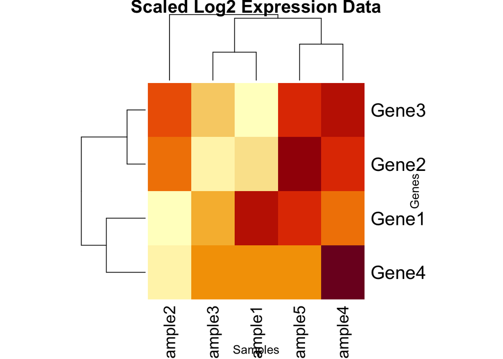

```r
# Create a sample matrix
sample_matrix <- matrix(rnorm(20, mean=100, sd=20), nrow=4, ncol=5)
rownames(sample_matrix) <- paste0("Gene", 1:4)
colnames(sample_matrix) <- paste0("Sample", 1:5)

# Log transform
log_data <- log2(sample_matrix)

# Scale rows
scaled_data <- t(scale(t(log_data)))

# Create heatmap
heatmap(scaled_data,
        main = "Scaled Log2 Expression Data",
        xlab = "Samples",
        ylab = "Genes",
        scale = "none")  # Already scaled
```

## Next Steps

After mastering vectors and matrices, you can move on to: - Working with data frames - Statistical analysis and hypothesis testing - Advanced visualization techniques - Machine learning applications in R